# Projekt RPiSM - Eurobiznes

Jakub Anczyk

2022-12-20

## Projekt RPiSM, zadanie nr 2

Do projektu wybrałem zadanie 2, które wydało mi się najciekawsze. Badane zdarzenie polegało na postawieniu pionka zarówno na elektrowni jak i sieci wodociągów, ale ominięciu każdej kolei.

Postanowiłem zinterpretować zadanie w ten sposób, że w trakcie 7 rzutów kostką suma oczek w dowolnym momencie musi wynieść zarówno 12 jak i 28 (odpowiednio elektrownia i sieć wodociągów), ale nie może wynieść 5, 15, 25 oraz 35 (pola odpowiadające kolejom).

```r
omega <- 6^7
omega2 <- 6^6
pola_wymagane <- c(12, 28)
pola_zakazane <- c(5, 15, 25, 35)
```

### Wstępne obliczenia

Przy ograniczeniu do 7 rzutów kostką, przestrzeń zdarzeń elementarnych omega będzie równa $6^7$, a więc **279936**.

Do analizy możliwych kombinacji wybrałem metodę polegającą na wykorzystaniu funkcji expand.grid(), która umożliwia szybkie wygenerowanie ramki danych zawierającej wszystkie kombinacje wskazanych wektorów.

Po zweryfikowaniu ilość wierszy wynosi rzeczywiście **279936**, czyli pokrywa się z przewidzianą liczbą kombinacji.

```r
eurobiznes <- expand.grid(r1 = 1:6, r2 = 1:6, r3 = 1:6, r4 = 1:6, r5 = 1:6, r6 = 1:6, r7 = 1:6)
```

Następnie, aby móc sprawdzić, czy w trakcie ruchu kostką spełniliśmy wszystkie 6 założeń wspomnianych na wstępie, musimy wygenerować kolejne sumy rzutów dla wszystkich kombinacji. W tym celu użyłem funkcji mutate z pakietu dplyr.

```r
eurobiznes <- eurobiznes %>%
  mutate(r0 = 1:omega,
         s1 = r1,
         s2 = s1 + r2,
         s3 = s2 + r3,
         s4 = s3 + r4,
         s5 = s4 + r5,
         s6 = s5 + r6,
         s7 = s6 + r7)
```

W kolejnym kroku dokonałem sprawdzenia, czy kolejne sumy danego wiersza spełniają wszystkie 6 założeń. Kod generuje wartość “1” jeżeli wyrzucone do danego momentu gry oczka sumują się do 12 i 28, lecz nie do 5, 15, 25 oraz 35. W przeciwnym razie kod generuje wartość “0”.

```r
eurobiznes$x1 <- eurobiznes$x <- ifelse((eurobiznes[,9] %in% pola_wymagane) == 2 & (eurobiznes[,9] %in% pola_zakazane) == 0, 1, 0)
eurobiznes$x2 <- eurobiznes$x <- ifelse(rowSums(sapply(eurobiznes[,9:10], `%in%`, pola_wymagane)) == 2 & rowSums(sapply(eurobiznes[,9:10], `%in%`, pola_zakazane)) == 0, 1, 0)
eurobiznes$x3 <- eurobiznes$x <- ifelse(rowSums(sapply(eurobiznes[,9:11], `%in%`, pola_wymagane)) == 2 & rowSums(sapply(eurobiznes[,9:11], `%in%`, pola_zakazane)) == 0, 1, 0)
eurobiznes$x4 <- eurobiznes$x <- ifelse(rowSums(sapply(eurobiznes[,9:12], `%in%`, pola_wymagane)) == 2 & rowSums(sapply(eurobiznes[,9:12], `%in%`, pola_zakazane)) == 0, 1, 0)
eurobiznes$x5 <- eurobiznes$x <- ifelse(rowSums(sapply(eurobiznes[,9:13], `%in%`, pola_wymagane)) == 2 & rowSums(sapply(eurobiznes[,9:13], `%in%`, pola_zakazane)) == 0, 1, 0)
eurobiznes$x6 <- eurobiznes$x <- ifelse(rowSums(sapply(eurobiznes[,9:14], `%in%`, pola_wymagane)) == 2 & rowSums(sapply(eurobiznes[,9:14], `%in%`, pola_zakazane)) == 0, 1, 0)
eurobiznes$x7 <- eurobiznes$x <- ifelse(rowSums(sapply(eurobiznes[,9:15], `%in%`, pola_wymagane)) == 2 & rowSums(sapply(eurobiznes[,9:15], `%in%`, pola_zakazane)) == 0, 1, 0)
```

### Zadanie 1

Żeby wykonać zadanie pierwsze, zsumowałem wszystkie zdarzenia, wktórych po siódmym rzucie wszystkie sześć założeń było spełnione. Ostatecznie zdarzeń tych było **3940**. Porównując tę wartość do liczby zdarzeń elementarnych, otrzymujemy prawdopodobieństwo równe **1.41%**.

```r
zadanie1 <- ((sum(eurobiznes$x7 == 1)/omega)*100)
```

### Zadanie 2

Do wykonania zadanie drugiego wystarczyło wyfiltrować wszystkie zdarzenia, w których pierwszą cyfrą było “3” i przyrównać do sumy zdarzeń elementarnych która będzie równa $6^6$ czyli **46656**. Zdarzeń tych było **602**, co daje nam odpowiednio prawdopodobieństwo rzędu **1.29%**.

```r
zadanie2 <- ((sum(eurobiznes$x7 == 1 & eurobiznes$r1 == 3)/(omega2))*100)

suma_zdarzen <- eurobiznes %>%
  select(x1:x7) %>%
  summarise(across(x1:x7, sum))
```

### Zadanie 3

Wykonanie zadanie trzeciego polegało na sprawdzeniu, w którym rzucie kostką, spełnienie wszystkich sześciu założeń było najbardziej prawdopodobne. W tym celu zsumowałem ilość zdarzeń, w których warunki zostały spełnione i przypisałem zmiennej K wartość odpowiadającą pozycji tej kolumny. W tym przypadku to kolumna o numerze **7**.

Zatem spełnienie wszystkich warunków zadania było najbardziej prawdopodobne w rzucie o numerze **7**.

```r
zadanie3 <- max.col(suma_zdarzen)
K <- zadanie3
```

### Zadanie 4

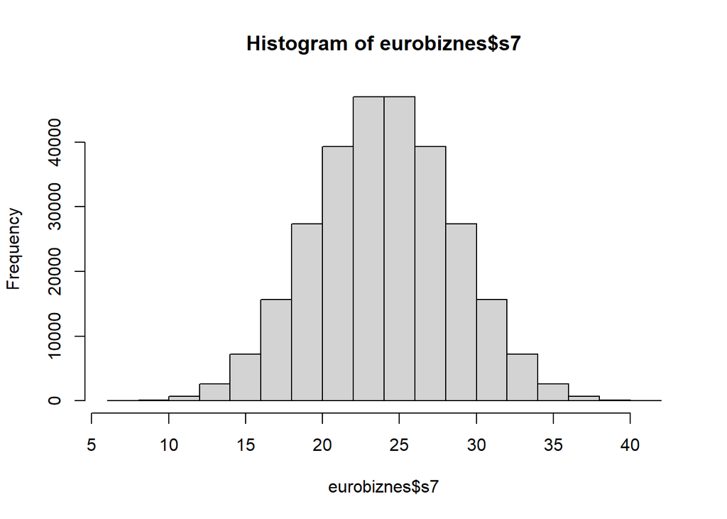

```r
zadanie4a <- hist(eurobiznes$s7)
```

```r
zadanie4b <- ggplot(eurobiznes, aes(x=s7)) + stat_ecdf(geom = "step", color="black")

zadanie4a
```

```
## $breaks
##  [1]  6  8 10 12 14 16 18 20 22 24 26 28 30 32 34 36 38 40 42
##
## $counts
##  [1]     8   112   672  2584  7224 15680 27384 39320 46984 46984 39320 27384
## [13] 15680  7224  2584   672   112     8
##
## $density
##  [1] 0.000014 0.000200 0.001200 0.004615 0.012903 0.028006 0.048911 0.070230
##  [9] 0.083919 0.083919 0.070230 0.048911 0.028006 0.012903 0.004615 0.001200
## [17] 0.000200 0.000014
##
## $mids
##  [1]  7  9 11 13 15 17 19 21 23 25 27 29 31 33 35 37 39 41
##
## $xname
## [1] "eurobiznes$s7"
##
## $equidist
## [1] TRUE
##
## attr(,"class")
## [1] "histogram"
```

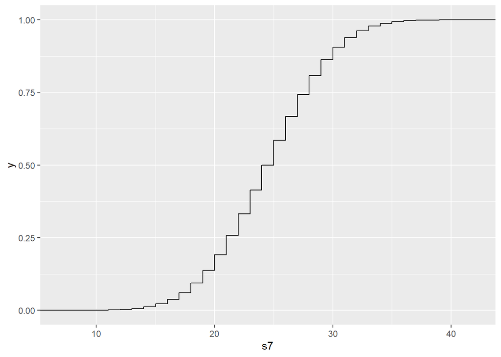

```r
zadanie4b
```

### Zadanie 5

Do zadanie piątego i testu centralnego twierdzenia granicznego posłużyłem się pętlą for() i funkcją sample() aby wygenerować n (1000) sum siedmiokrotnych losowych rzutów kostką.

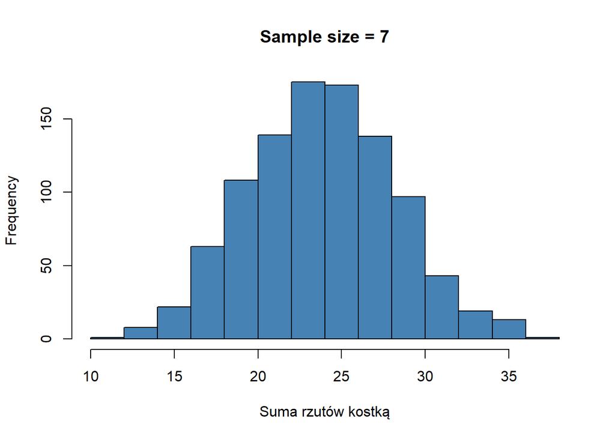

```r
sample5 <- c()
n = 1000

for (i in 1:n){
  sample5[i] = mean(sample(eurobiznes$s7, 1, replace=TRUE))
}

zadanie5b <- hist(sample5, col ='steelblue', xlab='Suma rzutów kostką', main='Sample size = 7')
```

```r
zadanie5b
```

```
## $breaks
##  [1] 10 12 14 16 18 20 22 24 26 28 30 32 34 36 38
##
## $counts
##  [1]   1   8  22  63 108 139 175 173 138  97  43  19  13   1
##
## $density
##  [1] 0.0005 0.0040 0.0110 0.0315 0.0540 0.0695 0.0875 0.0865 0.0690 0.0485
## [11] 0.0215 0.0095 0.0065 0.0005
##
## $mids
##  [1] 11 13 15 17 19 21 23 25 27 29 31 33 35 37
##
## $xname
## [1] "sample5"
##
## $equidist
## [1] TRUE
##
## attr(,"class")
## [1] "histogram"
```

Na tak wygenerowanych danych przeprowadziłem test przy pomocy funkcji shapiro.test().

```r
zadanie5test <- shapiro.test(sample5)
zadanie5test
```

```
##
##  Shapiro-Wilk normality test
##
## data:  sample5
## W = 1, p-value = 0.0005
```

### Zadanie 6

Zadanie szóste wymagało innego podejścia niż pierwsza część, ponieważ wygenerowanie macierzy zdarzeń dla K (7) rzutów kostką i 50 próbek wymagałoby wielu GB pamięci.

Zamiast tego zdefiniowałem w pamięci określone kostki jako wektory i dla każdej z kostek zdefiniowałem po jednej tablicy dla wyników rzutów kostką.

```r
kostka1 <- c(1, 2, 6, 7)
kostka2 <- c(3, 4, 5, 8)

sample6a <- tibble()
sample6b <- tibble()

m = 50

for (i in 1:m){
  for (j in 1:K){
    sample6a[i,j] = sample(kostka1, 1, replace=TRUE)
    sample6b[i,j] = sample(kostka2, 1, replace=TRUE)
  }
}
```

Następnie dla każdego wiersza obliczyłem sumę oraz wariancję wylosowanych wartości.

```r
sample6a$sum <- rowSums(sample6a[,1:K])
sample6b$sum <- rowSums(sample6b[,1:K])

sample6a$var <- rowVars(as.matrix(sample6a[,c(1:K)]))
sample6b$var <- rowVars(as.matrix(sample6b[,c(1:K)]))
```

Na koniec wykonałem testy t.test() oraz var.test() dla odpowiednich kolumn sum i wariancji.

```r
zadanie6test1 <- t.test(sample6a$sum, sample6b$sum, var.equal=FALSE)
zadanie6test1
```

```
##
##  Welch Two Sample t-test
##
## data:  sample6a$sum and sample6b$sum
## t = -5, df = 90, p-value = 1e-05
## alternative hypothesis: true difference in means is not equal to 0
## 95 percent confidence interval:
##  -7.2 -2.9
## sample estimates:
## mean of x mean of y
##        29        34
```

```r
zadanie6test2 <- var.test(sample6a$var, sample6a$var)
zadanie6test2
```

```
##
##  F test to compare two variances
##
## data:  sample6a$var and sample6a$var
## F = 1, num df = 49, denom df = 49, p-value = 1
## alternative hypothesis: true ratio of variances is not equal to 1
## 95 percent confidence interval:
##  0.57 1.76
## sample estimates:
## ratio of variances
##                  1
```

Test dwóch próbek Welcha dla średnich sugeruje, że istnieje statystycznie istotna różnica między wartościami sum wierszy obu grup. Wartość p jest mniejsza niż 0,05, co wskazuje, że różnica między dwiema próbami jest mało prawdopodobna, aby wynikała z przypadku. Sugeruje to, że obie próby mają różne średnie i że różnica ta jest statystycznie istotna.